# Hammel: Milestone 1 Validation

Author

Aaron Gullickson

Published

October 15, 2026

## 1 Purpose and completion criteria

Assess whether the current simulator can reproduce the supplied demographic schedules of fertility and mortality over the simulation period adequately for milestone 1. For this assessment, the input fertility and mortality rates will be held constant across the simulation.

| Measure | Comparison | Acceptance criterion |
| --- | --- | --- |
| ASFR | Output births / female exposure versus input rates | Adequate coverage of 95% CI of mean ASFR for each age group and time period over true input ASFR |
| TFR | Output versus input TFR over matched ages | Adequate coverage of 95% CI of mean TFR across iterations over true input TFR for all time periods |
| ASMR | Output deaths / exposure versus input rates, by sex | Adequate coverage of 95% CI of mean ASMR for each age group and time period over true input ASFR |
| Life expectancy | Output versus input-derived life table | Adequate coverage of 95% CI of mean life expectancy across iterations over true input TFR for all time increments |
| Stable Population | Simulation output to Leslie matrix projection | On average, microsimulation population dynamics should converge to expected stable population growth rate and age distribution |
| Birth spacing and accounting | Existing tests and checks on simulated histories | Successful unit tests |

Our primary measure of acceptance will be that the true values for each measure fall within the 95% confidence interval of the mean estimate from the simulation. However, because we will be performing this test for a large number of points, we do expect that not every point will fall within that 95% CI.

## 2 Inputs and simulation design

```r
# country to pull HFD/HMD data
country <- "USA"
# year to pull HFD/HMD data and also the beginning year of sim
start_time <- 2000
# years to run simulation
years <- 100
# ending time of the simulation
end_time <- start_time + years
# initial population construction parameters
population_size <- 100000
max_age <- 100
# minimum birth interval in years (0.75 = 9 months)
birth_interval <- 0.75
# seeds for random processes
population_seed <- 42
replication_seeds <- seq_len(100)
```

### 2.1 Prepare inputs

Fertility and mortality rates come from the Human Fertility Database and Human Mortality Database, respectively. The open-ended categories for under 13 and over 55 for fertility are excluded.

```r
mortality_rates <- get_mortality_hmd(country, start_time)
fertility_rates <- get_fertility_hfd(country, start_time)

input_tfr <- calculate_tfr(fertility_rates)
input_life_table <- calculate_life_table(mortality_rates)
input_life_expectancy <- input_life_table |>
  filter(age_start == 0) |>
  select(sex, ex)

input_tfr
```

```
# A tibble: 1 × 3
  age_start age_end   tfr
      <dbl>   <dbl> <dbl>
1        13      55  2.05
```

```r
input_life_expectancy
```

```
# A tibble: 2 × 2
  sex      ex
  <chr> <dbl>
1 m      74.1
2 f      79.4
```

```r
fertility_rates_niger <- read_csv(here("validation", "data", "niger_2012_asfr_wpp2024.csv"))
```

### 2.2 Initialization and observation windows

All replications below share one baseline population. They measure simulation variability conditional on that population. Baseline-generation variability would require a separate design.

Because of the arbitrary nature of the initial population, there will typically be a “burn-in” period before a stable population is achieved. Measures based on ASMR and ASFR still should be valid throughout, but population growth may be highly variable. However, because the simulation modifies actual fertility rates to account for non-exposure of mothers who recently gae birth, the initial ASFR and TFR estimates will be slightly higher because no women start will have recently given birth.

```r
set.seed(population_seed)
population <- create_baseline_population(
  population_size, max_age = max_age, end_time = start_time
)
model <- hammel_model() |>
  set_population(population) |>
  set_mortality(mortality_rates) |>
  set_fertility(fertility_rates, birth_interval = birth_interval)

fertility_time_breaks <- c(
  seq(start_time, start_time + 9, 1),
  seq(start_time + 10, end_time, 10)
)
mortality_time_breaks <- seq(start_time, end_time, 10)
# Finite last breakpoints automatically gain an open interval.
life_table_age_breaks <- 0:100
mortality_age_breaks <- 0:110
fertility_age_breaks <- sort(unique(c(
  0, fertility_rates$age_start, fertility_rates$age_end
)))
```

## 3 Replications and demographic extraction

The simulation is run 100 times and for each run, I calculate the lexis diagram to get person years, births, and deaths within given time and range brakets.

```r
results <- map(replication_seeds, function(seed) {
  simulate(model, years = years, seed = seed)
})
names(results) <- as.character(replication_seeds)

fertility_counts <- map(results, calculate_lexis_counts,
  time_breaks = fertility_time_breaks,
  age_breaks = fertility_age_breaks)
mortality_counts <- map(results, calculate_lexis_counts,
  time_breaks = mortality_time_breaks,
  age_breaks = mortality_age_breaks)
life_table_counts <- map(results, calculate_lexis_counts,
  time_breaks = fertility_time_breaks,
  age_breaks = life_table_age_breaks)

tfr <- map(fertility_counts, calculate_tfr) |>
  bind_rows(.id = "replication") |>
  mutate(time_mid = (time_start + time_end) / 2) |>
  select(replication, time_mid, tfr)
asfr <- bind_rows(fertility_counts, .id = "replication") |>
  filter(sex == "f") |>
  mutate(time_mid = (time_start + time_end) / 2,
         age_mid = (age_start + age_end) / 2) |>
  select(replication, time_mid, age_mid, asfr) |>
  filter(age_mid >= 13 & age_mid < 55)
asmr <- bind_rows(mortality_counts, .id = "replication") |>
  mutate(time_mid = (time_start + time_end) / 2,
         age_mid = (age_start + age_end) / 2) |>
  select(replication, time_mid, age_mid, sex, asmr)
life_expectancy <- map(life_table_counts, calculate_life_table) |>
  bind_rows(.id = "replication") |>
  mutate(time_mid = (time_start + time_end) / 2) |>
  filter(age_start == 0) |>
  select(replication, time_mid, sex, ex)
```

## 4 Fertility results

### 4.1 Total fertility rate

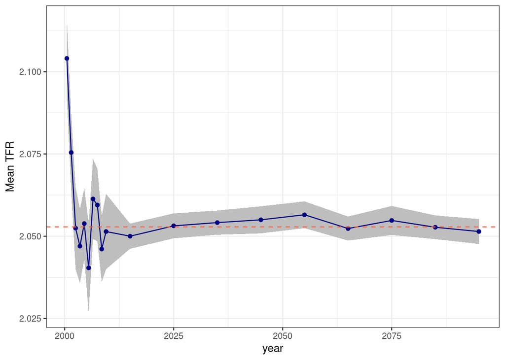

Figure 1: Mean TFR across 100 simulations by time period. Grey ribbon shows 95% confidence interval for the sample mean. Dotted line shows the true TFR based on the input age-specific fertility rates.

```r
tfr_summary <- tfr |>
  group_by(time_mid) |>
  summarize(
    mean = mean(tfr),
    sd = sd(tfr),
    n = n(),
    se = sd / sqrt(n),
    .groups = "drop"
  )

ggplot(tfr_summary, aes(x = time_mid, y = mean))+
  geom_ribbon(aes(ymin = mean - 1.96 * se, ymax = mean + 1.96 * se),
              color = NA, fill = "grey")+
  geom_line(color = "navy")+
  geom_point(color = "navy")+
  geom_hline(yintercept = input_tfr$tfr, linetype = 2, color = "tomato")+
  labs(x = "year", y = "Mean TFR")+
  theme_bw()
```

Figure 1 shows the mean TFR in each time period across the 100 replicated simulations. To account for the potential bias in the early simulation due to a lack of women with recent prior births, I use one year time periods for the first decade and then ten year periods for the remainder of the simulation.

As expected, there is some upward bias initially due to the fertility adjustments. However, this bias is removed after the first two years of the simulation. Every remaining estimate’s 95% confidence interval contains the true TFR and there is no evidence of a trend.

### 4.2 Age-specific fertility rates

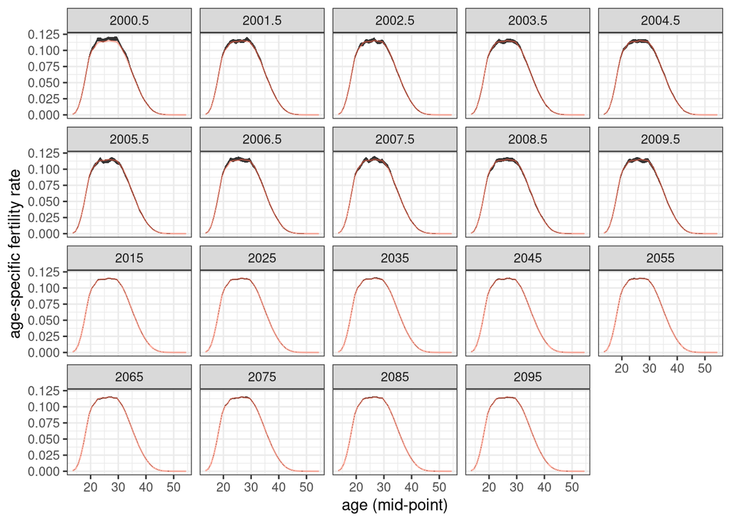

Figure 2: The figure shows age specific fertility rates from the input data in red and a 95% confidence interval for the mean of the age-specific fertility rates across 100 simulations, separately by time period.

```r
asfr_summary <- asfr |>
  group_by(time_mid, age_mid) |>
  summarize(
    mean = mean(asfr),
    sd = sd(asfr),
    n = n(),
    se = sd / sqrt(n),
    .groups = "drop"
  )

ggplot(asfr_summary, aes(x = age_mid, y = mean))+
  geom_ribbon(aes(ymin = mean - 1.96 * se, ymax = mean + 1.96 * se),
              color = NA, fill = "grey20")+
  #geom_line(color = "navy")+
  geom_line(data = fertility_rates, aes(x = age_start + 0.5, y = rate),
            color = "tomato", alpha = 0.5)+
  facet_wrap(~time_mid)+
  labs(x = "age (mid-point)", y = "age-specific fertility rate")+
  theme_bw()
```

Figure 2 shows a very close comparison between the estimated age-specific fertility rates across simulations and the input rates. The most notable differences are in the first two years, where the estimated rates are slightly higher, as expected.

```r
fertility_rates |>
  mutate(age_mid = (age_start + age_end) / 2) |>
  inner_join(asfr_summary, by = "age_mid") |>
  mutate(upper = mean + 1.96 * se, lower = mean - 1.96 * se,
         include = rate <= upper & rate >= lower) |>
  group_by(time_mid) |>
  summarize(
    n = n(),
    coverage = mean(include),
    max_abs_deviation = max(abs(mean - rate)),
    .groups = "drop"
  ) |>
  gt() |>
  cols_label(
    time_mid ~ "time period mid point",
    n ~ "age groups",
    coverage ~ "95% CI coverage",
    max_abs_deviation = "maximum absolute deviation"
  )
```

Table 1: Coverage of 95% confidence intervals for age-specific fertility rates by period.

| time period mid point | age groups | 95% CI coverage | maximum absolute deviation |
| --- | --- | --- | --- |
| 2000.5 | 42 | 0.7619048 | 0.0056116303 |
| 2001.5 | 42 | 0.9523810 | 0.0041367410 |
| 2002.5 | 42 | 0.9285714 | 0.0036715670 |
| 2003.5 | 42 | 0.9047619 | 0.0023178744 |
| 2004.5 | 42 | 0.9523810 | 0.0025140064 |
| 2005.5 | 42 | 0.8809524 | 0.0029718215 |
| 2006.5 | 42 | 0.8809524 | 0.0037506979 |
| 2007.5 | 42 | 0.8571429 | 0.0029634989 |
| 2008.5 | 42 | 0.9047619 | 0.0022025002 |
| 2009.5 | 42 | 0.9523810 | 0.0025262586 |
| 2015.0 | 42 | 0.9285714 | 0.0016895017 |
| 2025.0 | 42 | 1.0000000 | 0.0007103363 |
| 2035.0 | 42 | 0.9761905 | 0.0008256292 |
| 2045.0 | 42 | 0.9047619 | 0.0008555047 |
| 2055.0 | 42 | 0.9047619 | 0.0010351543 |
| 2065.0 | 42 | 0.9523810 | 0.0014507223 |
| 2075.0 | 42 | 0.9761905 | 0.0013151931 |
| 2085.0 | 42 | 0.9523810 | 0.0007730910 |
| 2095.0 | 42 | 0.9761905 | 0.0006053100 |

Table 1 shows the 95% CI coverage for each time period, as well as the maximum absolute deviation. As expected the early period has less coverage and more deviation, but coverage after the first ten years is overall as expected, with low maximum absolute deviation.

## 5 Mortality results

### 5.1 Life expectancy

Because of sparsity over age 100, it is difficult to calculate life expectancy on life tables that extend to an open interval at 110+ years, consistent with the input data from HMD. Therefore, I truncate the open ended interval here to 100, which may lead to a slight systematic bias relative to the life expectancy estimated directly from the HMD data. However, given that mortality is high and flattens out in this period, the bias is likely to be very small.

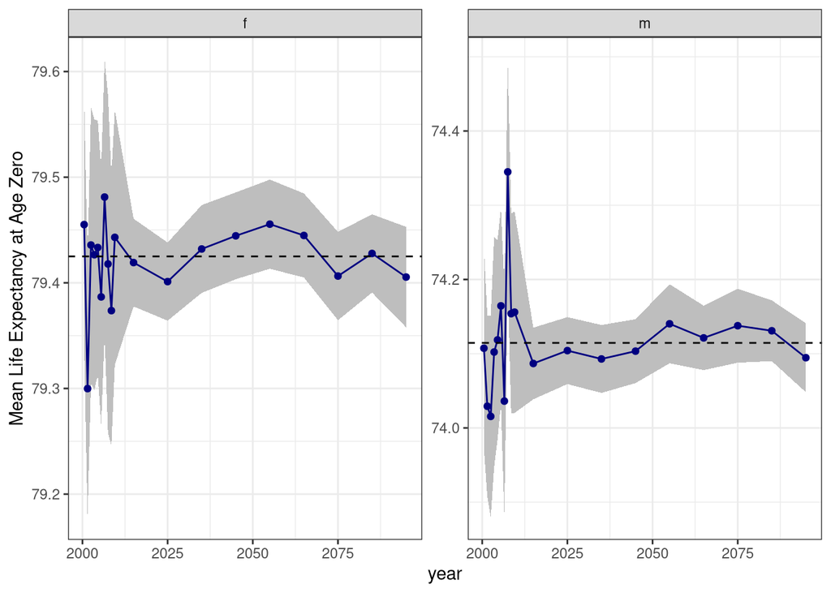

Figure 3: Mean life expectancy at age zero across 100 simulations by time period. Grey ribbon shows 95% confidence interval for the sample mean. Dotted line shows the true life expectancy based on the input age-specific mortality rates.

```r
life_exp_summary <- life_expectancy |>
  group_by(time_mid, sex) |>
  summarize(
    mean = mean(ex),
    sd = sd(ex),
    n = sum(!is.na(ex)),
    se = sd / sqrt(n),
    .groups = "drop"
  )

ggplot(life_exp_summary, aes(x = time_mid, y = mean))+
  geom_ribbon(aes(ymin = mean - 1.96 * se, ymax = mean + 1.96 * se),
              color = NA, fill = "grey")+
  geom_line(color = "navy")+
  geom_point(color = "navy")+
  geom_hline(data = input_life_expectancy, aes(yintercept = ex), linetype = 2)+
  facet_wrap(~sex, scales = "free_y")+
  labs(x = "year", y = "Mean Life Expectancy at Age Zero")+
  theme_bw()
```

Figure 3 shows how well the empirically estimated life expectancy fits to the life expectancy of the input mortality rates, separately by gender. In general, it fits very well. Only one estimate’s 95% confidence interval does not include the true input life expectancy, but this is quite plausibly a random error given the number of data points tested. I observe no trend here, nor any initial difficulty in the “burn in” period.

### 5.2 Age-specific mortality rates

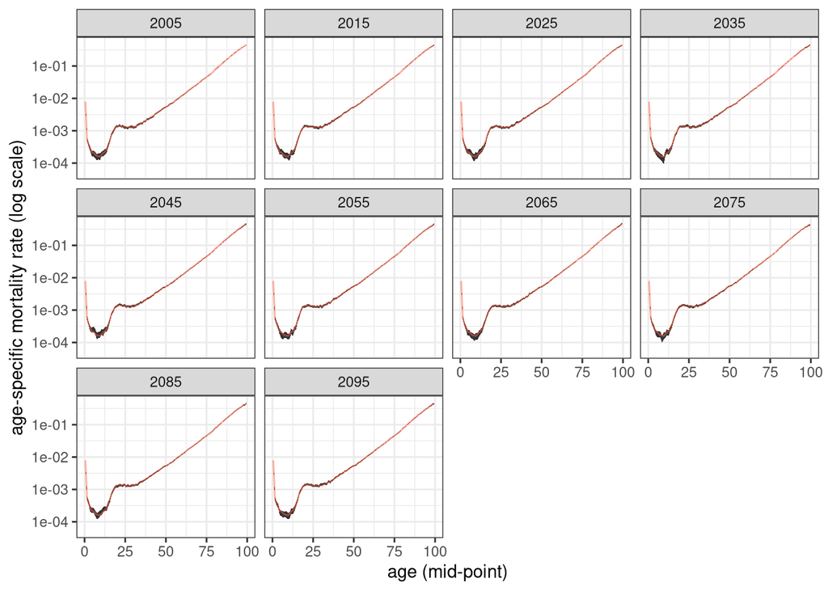

Figure 4: The figure shows male age specific mortality rates from the input data in red and a 95% confidence interval for the mean of the age-specific mortality rates across 100 simulations, separately by time period. Truncated at age 100 due to very small sample sizes at higher ages.

```r
asmr_summary <- asmr |>
  group_by(time_mid, age_mid, sex) |>
  summarize(
    mean = mean(asmr, na.rm = TRUE),
    sd = sd(asmr, na.rm = TRUE),
    n = sum(!is.na(asmr)),
    se = sd / sqrt(n),
    .groups = "drop"
  )

asmr_summary |>
  filter(sex == "m") |>
  ggplot(aes(x = age_mid, y = mean))+
  geom_ribbon(aes(ymin = mean - 1.96 * se, ymax = mean + 1.96 * se),
              color = NA, fill = "grey20")+
  geom_line(data = filter(mortality_rates, sex == "m"),
            aes(x = age_start + 0.5, y = rate),
            color = "tomato", alpha = 0.5)+
  facet_wrap(~time_mid)+
  scale_y_log10(limits = c(.00005, .5))+
  scale_x_continuous(limits = c(0, 100))+
  labs(x = "age (mid-point)", y = "age-specific mortality rate (log scale)")+
  theme_bw()
```

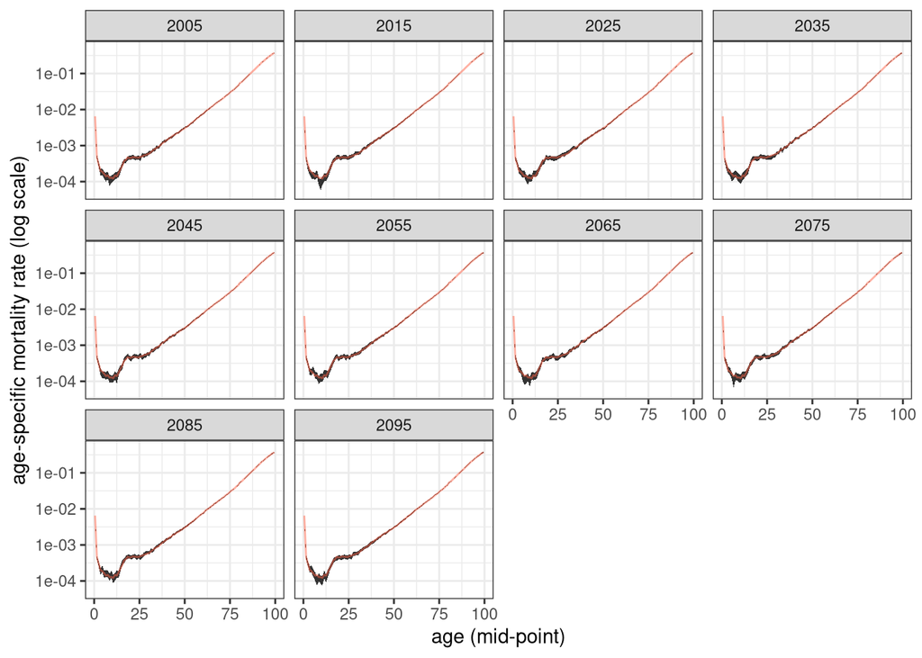

Figure 5: The figure shows female age specific mortality rates from the input data in red and a 95% confidence interval for the mean of the age-specific mortality rates across 100 simulations, separately by time period. Truncated at age 100 due to very small sample sizes at higher ages.

```r
asmr_summary |>
  filter(sex == "f") |>
  ggplot(aes(x = age_mid, y = mean))+
  geom_ribbon(aes(ymin = mean - 1.96 * se, ymax = mean + 1.96 * se),
              color = NA, fill = "grey20")+
  geom_line(data = filter(mortality_rates, sex == "f"),
            aes(x = age_start + 0.5, y = rate),
            color = "tomato", alpha = 0.5)+
  facet_wrap(~time_mid)+
  scale_y_log10(limits = c(.00005, .5))+
  scale_x_continuous(limits = c(0, 100))+
  labs(x = "age (mid-point)", y = "age-specific mortality rate (log scale)")+
  theme_bw()
```

Figure 4 and Figure 5 show the fit of male and female age-specific mortality rates, respectively, from the input schedules in comparison to the 95% CI of the mean ASFR for each simulation, across time. The simulated data fit extremely well to the expected input schedules.

```r
mortality_rates |>
  mutate(age_mid = (age_start + age_end) / 2) |>
  inner_join(asmr_summary, by = c("age_mid", "sex")) |>
  mutate(upper = mean + 1.96 * se, lower = mean - 1.96 * se,
         include = rate <= upper & rate >= lower) |>
  filter(!is.na(include), age_mid < 90) |>
  group_by(time_mid) |>
  summarize(
    n = n(),
    coverage = mean(include),
    max_abs_deviation = max(abs(mean - rate)),
    .groups = "drop"
  ) |>
  gt() |>
  cols_label(
    time_mid ~ "time period mid point",
    n ~ "age groups",
    coverage ~ "95% CI coverage",
    max_abs_deviation = "maximum absolute deviation"
  )
```

Table 2: Coverage of 95% confidence intervals for age-specific mortality rates by period. Ages above 90 are excluded due to low cell counts within simulations.

| time period mid point | age groups | 95% CI coverage | maximum absolute deviation |
| --- | --- | --- | --- |
| 2005 | 180 | 0.9333333 | 0.001014191 |
| 2015 | 180 | 0.9666667 | 0.001249921 |
| 2025 | 180 | 0.9611111 | 0.001748626 |
| 2035 | 180 | 0.9555556 | 0.001995319 |
| 2045 | 180 | 0.9444444 | 0.002149783 |
| 2055 | 180 | 0.9333333 | 0.002573694 |
| 2065 | 180 | 0.9500000 | 0.003110677 |
| 2075 | 180 | 0.9444444 | 0.002724964 |
| 2085 | 180 | 0.9777778 | 0.002200835 |
| 2095 | 180 | 0.9333333 | 0.006000892 |

Table 2 shows the 95% coverage and maximum absolute deviation of each time period for age groups younger than 90. After 90, relatively few survivors leads to very low cell counts. The results show good coverage and low deviation across the time period.

## 6 Population growth

First, I will build a leslie matrix projection from the inputs so I can compare this to the microsimulation and assess stable population characteristics.

```r
k <- 111

# calculate survival
survival <- input_life_table |>
  arrange(sex, age_start) |>
  group_by(sex) |>
  mutate(
    S = lead(Lx) / Lx,
    # adjust for survival into the open age group
    S = if_else(
      lead(age_end) == Inf,
      lead(Lx) * (-expm1(-lead(mx))) / Lx,
      S
    ),
    # open-ended age group gets exp(-mx)
    S = if_else(
      age_end == Inf,
      exp(-mx),
      S
    )
  ) |>
  ungroup() |>
  select(age_start, sex, S)

S_female <- survival |> filter(sex == "f") |> pull(S)
S_male <- survival |> filter(sex == "m") |> pull(S)

mat_f <- matrix(0, k, k)
mat_m <- matrix(0, k, k)
# fill the survival subdiagonals
mat_f[row(mat_f) == col(mat_f) + 1] <- S_female[1:(k - 1)]
mat_m[row(mat_f) == col(mat_f) + 1] <- S_male[1:(k - 1)]
# add the open ended case
mat_f[k, k] <- S_female[k]
mat_m[k, k] <- S_male[k]

# construct full LM (no first row yet)
lm <- rbind(
  cbind(mat_f, matrix(0, k, k)),
  cbind(matrix(0, k, k), mat_m)
)

# now add first row
ffab <- 0.4886

fert <- survival |>
  filter(sex == "f") |>
  arrange(age_start) |>
  left_join(
    fertility_rates |> select(age_start, rate),
    by = "age_start"
  ) |>
  mutate(
    rate = coalesce(rate, 0),
    fx = (rate + S * lead(rate, default = 0)) / 2
  )

# First-year newborn survival, assuming annual bands and radix 1.
L0_f <- input_life_table |>
  filter(sex == "f", age_start == 0) |>
  pull(Lx)

L0_m <- input_life_table |>
  filter(sex == "m", age_start == 0) |>
  pull(Lx)

female_columns <- fert$age_start + 1L

lm[1, female_columns] <- ffab * L0_f * fert$fx
lm[k + 1, female_columns] <- (1 - ffab) * L0_m * fert$fx

eig <- eigen(lm)
lambda <- Re(eig$values[1])
stable <- Re(eig$vectors[, 1])
pop_stable <- stable / sum(stable)

r_stable <- log(lambda)
```

```r
# get starting population with women and men stacked
pop_start <- population$persons |>
  mutate(age = floor(population$end_time - birth_time)) |>
  group_by(sex, age) |>
  summarize(n = n(), .groups = "drop") |>
  complete(
    sex = c("f", "m"),
    age = 0:(k - 1),
    fill = list(n = 0L)
  ) |>
  arrange(sex, age) |>
  pull(n)

# project for 150 years
pop <- pop_start
pop_mat <- cbind(pop)
for(i in 1:150) {
  pop_next <- drop(lm %*% pop)
  pop_mat <- cbind(pop_mat, pop_next)
  pop <- pop_next
}
colnames(pop_mat) <- NULL

pop_total_lm <- apply(pop_mat, 2, sum)
```

```r
population_counts <- map(
  results,
  calculate_population_size,
  times = seq(start_time, end_time, 10)
) |>
  bind_rows(.id = "replication")
```

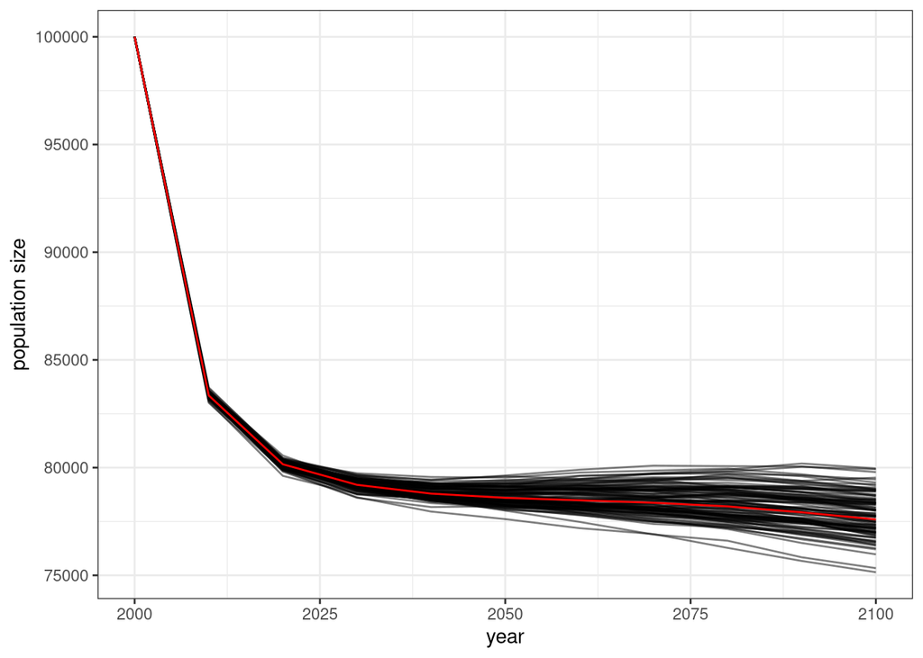

Figure 6: Size of the population across 100 simulation at 10 year intervals. The red line shows the results of a leslie matrix projection from the same input.

```r
pop_proj <- tibble(
  time = seq(from = 2000, to = 2100, by = 10),
  population = pop_total_lm[seq(from = 1, to = 101, by = 10)]
)

population_counts |>
  ggplot(aes(x = time, y = population))+
  geom_line(alpha = 0.5, aes(group = replication))+
  geom_line(data = pop_proj, color = "red", alpha = 1)+
  labs(x = "year", y = "population size")+
  theme_bw()
```

Figure 6 shows the population trajectory of each simulation over the simulation period. Because the simulation holds fertility and mortality rates constant, we should eventually reach a stable population trajectory. However, because the initial population provided did not match the age distribution of the expected stable population, we expect that the initial period will be highly variable. This is the “burn in” period. In this case, we get rapid population decline. The decline occurs because the initial population was uniformly distributed from zero to a hundred years of age and thus over-represented older people with high mortality. This decline levels off by 2025 and by 2050 appears to be approaching a stable gradual rate of decline.

Notably, the spread of population projection outcomes fits well to the leslie matrix projection with dispersion driven by the underlying random processes (while the leslie matrix projection has no randomness).

To analyze that rate of decline more formally, I can use the stable population growth rate returned from the leslie matrix:

```r
r_stable
```

```
[1] -0.0004451753
```

I can also confim that this growth rate is very close to the approximation of the stable population growth rate given by:

$$\frac{log(NRR)}{\mu}$$

where $\mu$ is the mean age of childbearing (i.e. generational length).

```r
temp <- input_life_table |>
  filter(sex == "f") |>
  select(age_start, Lx) |>
  inner_join(fertility_rates, by = "age_start")
NRR <- 0.4886 * sum(temp$rate * temp$Lx)
mu <- sum(((temp$age_start + temp$age_end) / 2) * temp$rate)/sum(temp$rate)
growth_stable <- log(NRR)/mu
growth_stable
```

```
[1] -0.000444936
```

The stable growth rate from these input fertility and mortality rates is a very small negative growth rate. Now I will estimate the actual growth rate in my simulation for each decade and take the mean across simulations.

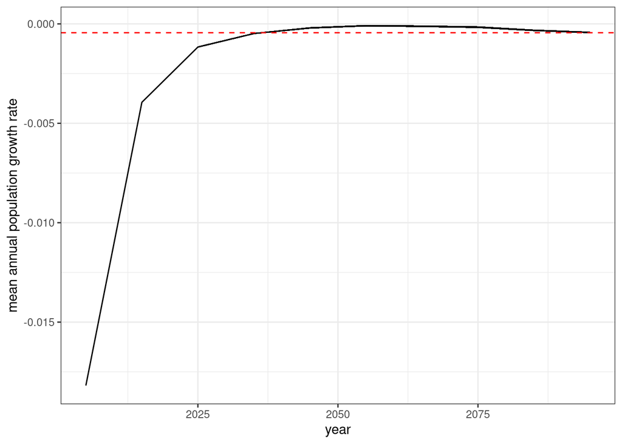

Figure 7: Annual population growth by decade. The mean is shown across all simulations with a 95% confidence interval given by the bands. The dotted red line shows the expected stable populationg growth rate.

```r
population_counts |>
  group_by(replication) |>
  arrange(time, .by_group = TRUE) |>
  mutate(rate_growth = log(lead(population) / population) / (lead(time) - time)) |>
  ungroup() |>
  filter(!is.na(rate_growth)) |>
  group_by(time) |>
  summarize(
    mean = mean(rate_growth),
    sd = sd(rate_growth),
    n = n(),
    se = sd / sqrt(n),
    .groups = "drop"
  ) |>
  ggplot(aes(x = time+5))+
  geom_ribbon(aes(ymin = mean - 1.96 * se, ymax = mean + 1.96 * se))+
  geom_line(aes(y = mean))+
  geom_hline(yintercept = r_stable, linetype = 2, color = "red")+
  labs(x = "year", y = "mean annual population growth rate")+
  theme_bw()
```

Figure 7 shows that the population growth rate is approaching the stable population growth rate by the end of the period. A longer simulation would allow a better assessment of whether it will stay at that growth rate. To accomplish this and to also test how well the simulation when resuing output data as new input data, I extend the simulations an additional 100 years.

```r
results_ext <- map2(results, replication_seeds, function(result, seed) {
  model <- model |>
    set_population(result)
  simulate(model, years = years, seed = seed)
})
```

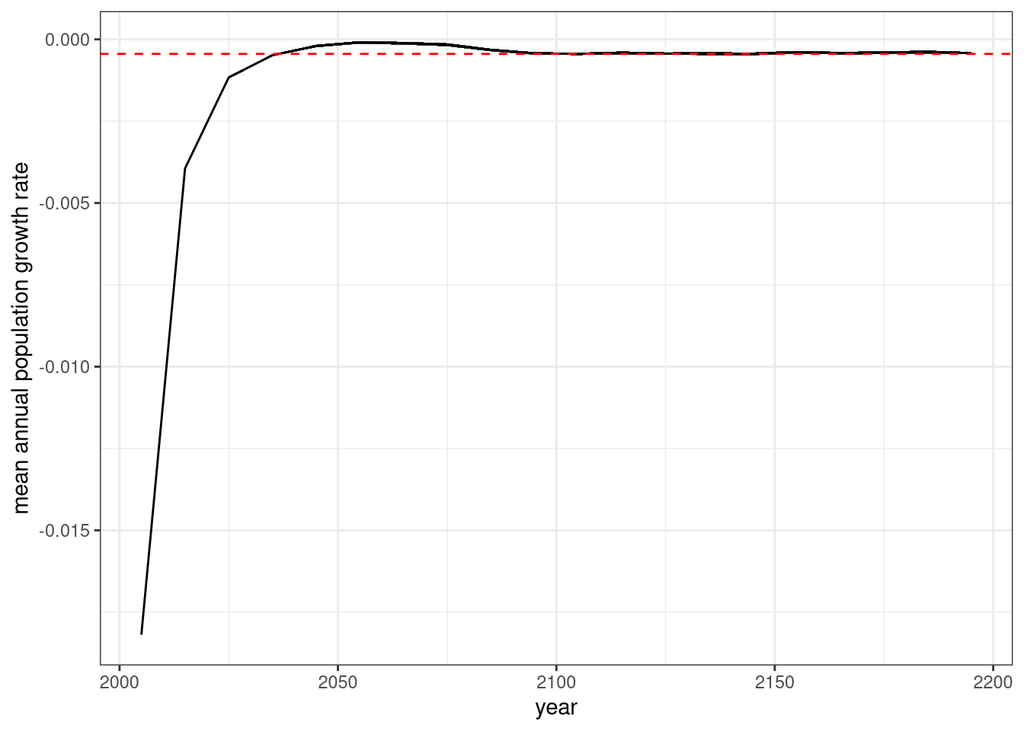

Figure 8: Annual population growth by decade with an additional 100 yars added to simulation. The mean is shown across all simulations with a 95% confidence interval given by the bands. The dotted red line shows the expected stable populationg growth rate.

```r
map(
  results_ext,
  calculate_population_size,
  times = seq(start_time, end_time + years, 10)
) |>
  bind_rows(.id = "replication") |>
  group_by(replication) |>
  arrange(time, .by_group = TRUE) |>
  mutate(rate_growth = log(lead(population) / population) / (lead(time) - time)) |>
  ungroup() |>
  filter(!is.na(rate_growth)) |>
  group_by(time) |>
  summarize(
    mean = mean(rate_growth),
    sd = sd(rate_growth),
    n = n(),
    se = sd / sqrt(n),
    .groups = "drop"
  ) |>
  ggplot(aes(x = time+5))+
  geom_ribbon(aes(ymin = mean - 1.96 * se, ymax = mean + 1.96 * se))+
  geom_line(aes(y = mean))+
  geom_hline(yintercept = r_stable, linetype = 2, color = "red")+
  labs(x = "year", y = "mean annual population growth rate")+
  theme_bw()
```

Figure 8 shows the same average growth rate after adding 100 more years to the simulation. The figure clearly shows that the population is converging toward a static population growth rate consistent with the stable population expectation.

As a final check on whether the simulations are producing a stable population outcome, I can compare the proportions of the population in each age group at the end of the simulation to the stable population proportions derived from the leslie matrix.

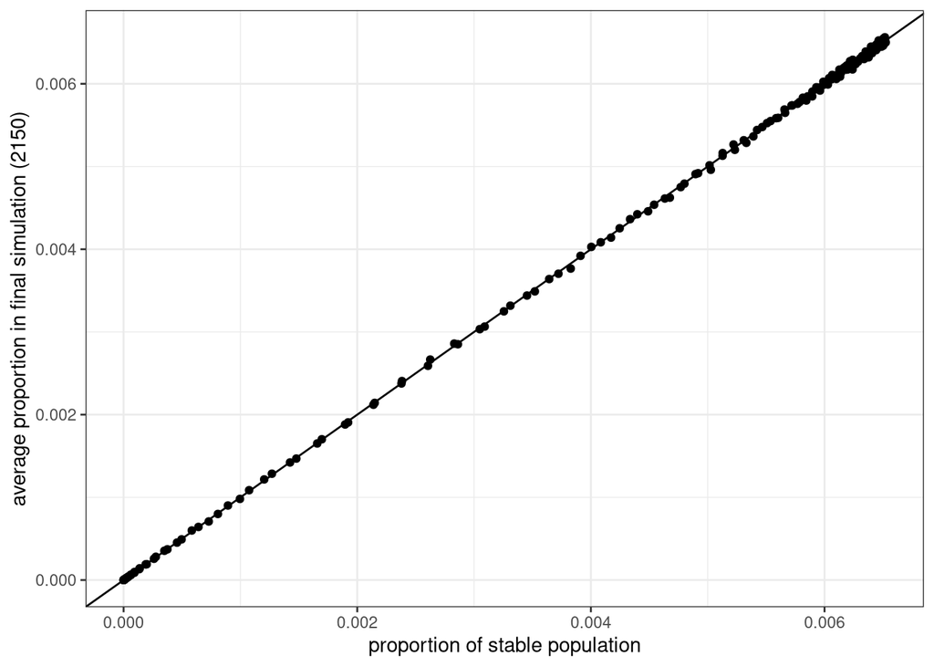

Figure 9: Comparison of proportions in each gender and age group based on the stable population and final population after simulation for 100 years, averaged across all simulations.

```r
age_dists <- results_ext |>
  map(function(result) {
    result$persons |>
      filter(is.na(death_time)) |>
      mutate(age = pmin(floor(result$end_time - birth_time), k - 1)) |>
      group_by(sex, age) |>
      summarize(n = n(), .groups = "drop") |>
      complete(
        sex = c("f", "m"),
        age = 0:(k - 1),
        fill = list(n = 0L)
      ) |>
      arrange(sex, age) |>
      mutate(prop = n / sum(n)) |>
      pull(prop)
  })
# get mean proportions
pop_sim <- Reduce(`+`, age_dists) / length(age_dists)

tibble(pop_sim, pop_stable) |>
  ggplot(aes(pop_stable, pop_sim))+
  geom_abline(yintercept = 0, slope = 1)+
  geom_point()+
  labs(x = "proportion of stable population", y = "average proportion in final simulation (2150)")+
  theme_bw()
```

Figure 9 shows that the empirical age distribution from the simulation fits very closely to the expected proportions of the stable population, determined from the Leslie matrix. This finding confirms that the microsimulations are correctly converging to stable populations.

## 7 Fertility Adjustment and Restart Issue

The simulation includes a `birth_interval` variable that defaults to 0.75 (9 months) as a minimum length between births. Because women will spend some time not exposed to the risk of birth, the actual fertility rates used to determine waiting time until birth must be higher than the provided age specific fertility rates in order for the simulation to match those input fertility rates. For a simple static fertility rate $f$, this adjustment would be

$$\frac{f}{1-bf}$$

where $b$ is the birth interval. With age-specific fertility rates, its somewhat more complicated as some of that 9 months may be spent outside the current age bracket and thus in a different fertility. The simulation currently uses the midpoint of the interval and assigns a duration weighted sum of ASFRs. For example, in the 20-21 age bracket, the mid point would be 20.5. 0.5 of the birth interval would then be within this bracket using $f_{20}$ and 0.25 would be in the previous bracket (19-20) and use $f_{19}$. So the adjustment in this case would be:

$$\frac{f_{20}}{1-(0.5)(f_{20})-(0.25)(f_{19})}$$

The results above show that this adjustment works very well to correctly reproduce the input ASFR and TFR in the output. The only issue is that when starting with a population consisting of women with no recent previous births (or any births), fertility will be overestimated for the first one or two years. Generally, we can chalk this up to the “burn in” period.

However, there is one remaining issue that may arise when a simulation is extended with a new fertility schedule. The adjustment made to fertility in the new simulation will be determined by the new fertility schedule but should be determined by a mix of old and new as some women will have been partially ineligible under the old system. When fertility is increased this will likely lead to a positive bias and when fertility is decreased this will lead to a negative bias.

To see how much of an issue this makes, I will extend our original simulation but replace the US fertility rates with those from Niger in 2012 (about 7.5 TFR).

```r
results_ext_niger <- map2(results, replication_seeds, function(result, seed) {
  model <- model |>
    set_population(result) |>
    set_fertility(fertility_rates_niger)
  simulate(model, years = 20, seed = seed)
})
```

```r
fertility_counts_ext_niger <- map(
  results_ext_niger,
  calculate_lexis_counts,
  time_breaks = c(2090:2110),
  age_breaks = fertility_age_breaks
)

tfr_ext_niger <- map(fertility_counts_ext_niger, calculate_tfr) |>
  bind_rows(.id = "replication") |>
  mutate(time_mid = (time_start + time_end) / 2) |>
  select(replication, time_mid, tfr)
```

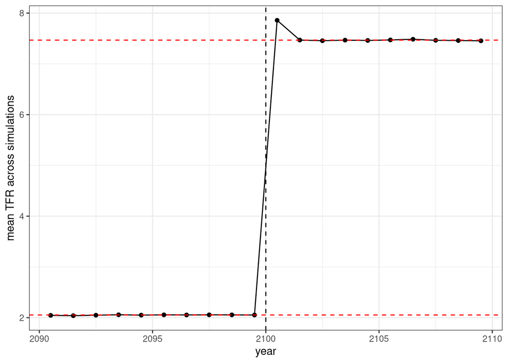

Figure 10: Mean TFR across simulations before and after a simulation restart using Niger’s 2012 fertility rates (TFR 7.46). The red dotted lines show the expected TFR under the two scenarios and the dotted vertical line shows the transition between the restart of the simulation.

```r
tfr_ext_niger |>
  group_by(time_mid) |>
  summarize(
    mean = mean(tfr),
    sd = sd(tfr),
    n = n(),
    se = sd / sqrt(n)
  ) |>
  ggplot(aes(x = time_mid, y = mean))+
  geom_point()+
  geom_line()+
  geom_hline(yintercept = c(input_tfr$tfr, sum(fertility_rates_niger$rate)),
             linetype = 2, color = "red")+
  geom_vline(xintercept = 2100, linetype = 2)+
  labs(x = "year", y = "mean TFR across simulations")+
  theme_bw()
```

Figure 10 shows the results for mean estimated TFR across the 100 simulations near the transition in restarting the simulation. There is a very clear single year blip immediately after the restart where fertility rates are higher than expected. This blip only lasts for the first year of the simulation, but if `birth_interval` was set higher, the bias could last longer.

```r
results_ext_nigerl <- map2(results, replication_seeds, function(result, seed) {
  model <- model |>
    set_population(result) |>
    set_fertility(fertility_rates_niger,  birth_interval = 1.25)
  simulate(model, years = 20, seed = seed)
})
```

```r
fertility_counts_ext_nigerl <- map(
  results_ext_nigerl,
  calculate_lexis_counts,
  time_breaks = c(2090:2110),
  age_breaks = fertility_age_breaks
)

tfr_ext_nigerl <- map(fertility_counts_ext_nigerl, calculate_tfr) |>
  bind_rows(.id = "replication") |>
  mutate(time_mid = (time_start + time_end) / 2) |>
  select(replication, time_mid, tfr)
```

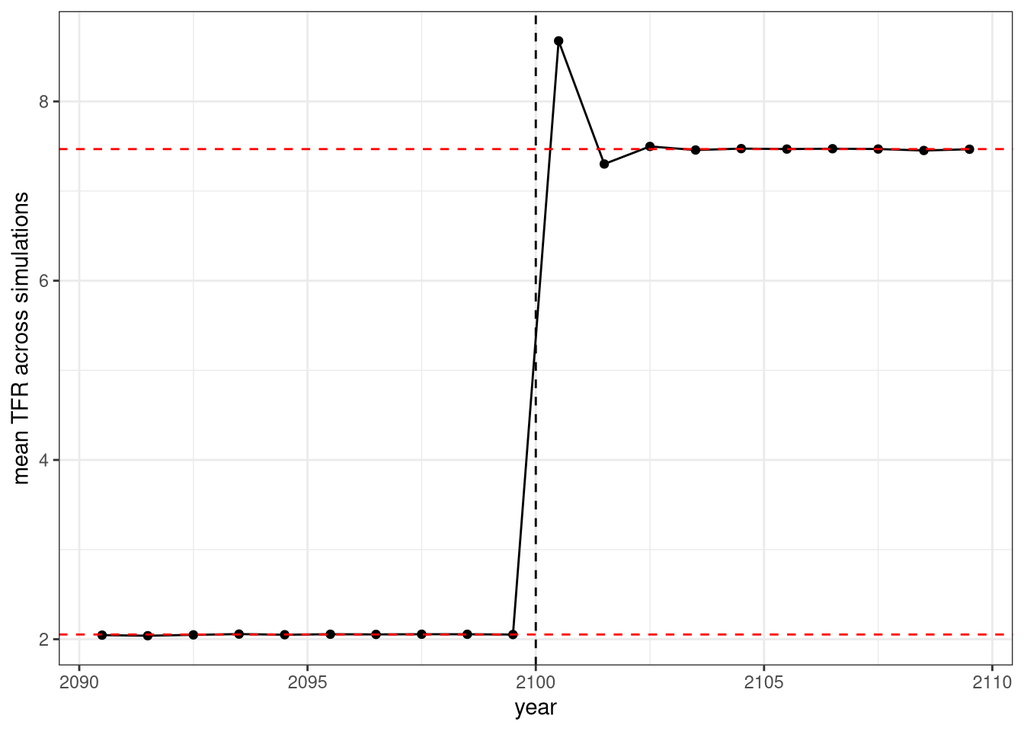

Figure 11: Mean TFR across simulations before and after a simulation restart using Niger’s 2012 fertility rates (TFR 7.46) and a longer minimum birth interval of 1.25 years. The red dotted lines show the expected TFR under the two scenarios and the dotted vertical line shows the transition between the restart of the simulation.

```r
tfr_ext_nigerl |>
  group_by(time_mid) |>
  summarize(
    mean = mean(tfr),
    sd = sd(tfr),
    n = n(),
    se = sd / sqrt(n)
  ) |>
  ggplot(aes(x = time_mid, y = mean))+
  geom_point()+
  geom_line()+
  geom_hline(yintercept = c(input_tfr$tfr, sum(fertility_rates_niger$rate)),
             linetype = 2, color = "red")+
  geom_vline(xintercept = 2100, linetype = 2)+
  labs(x = "year", y = "mean TFR across simulations")+
  theme_bw()
```

Figure 11 shows the same result but for a minimum birth interval of 1.25. The spike in the first year of the restart is more pronounced and there is some disturbance in subsequent years before once again hitting the expected TFR.

Ultimately, this is an issue which we should try to address. However, it is unlikely to cause substantial issues in most cases. The distortion observed here was generated by an extreme change in ASFR and in most cases simulations will not shift ASFR this much in a single restart so the actual bias will be much smaller.

## 8 Speed Tests

I want to see how quickly the simulation runs under different specifications in terms of the base size of the population, how long the simulation is run, and whether the population is roughly stationary or growing.

```r
scenarios <- tribble(
  ~pop_size, ~time, ~growth,
  10000,     50,    "stationary",
  50000,     50,    "stationary",
  100000,    50,    "stationary",
  200000,    50,    "stationary",
  10000,     100,   "stationary",
  50000,     100,   "stationary",
  100000,    100,   "stationary",
  200000,    100,   "stationary",
  10000,     200,   "stationary",
  50000,     200,   "stationary",
  100000,    200,   "stationary",
  200000,    200,   "stationary",
  10000,     50,    "growth",
  50000,     50,    "growth",
  100000,    50,    "growth",
  200000,    50,    "growth",
  10000,     100,   "growth",
  50000,     100,   "growth",
  100000,    100,   "growth",
  200000,    100,   "growth",
  10000,     200,   "growth",
  50000,     200,   "growth",
  100000,    200,   "growth",
  200000,    200,   "growth"
)

elapsed_time <- NULL
for(i in seq_along(1:nrow(scenarios))) {
  pop_size <- scenarios$pop_size[i]
  time <- scenarios$time[i]
  growth <- scenarios$growth[i]
  pop_test <- create_baseline_population(
    pop_size, max_age = 80, end_time = 0
  )
  if (growth == "stationary") {
    fert_test <- fertility_rates
  } else {
    # niger's fertility rates are so high that exponential growth over 200
    # years will explode the population and blow up RAM, so halve the rates
    fert_test <- fertility_rates_niger
    fert_test$rate <- fert_test$rate / 2
  }
  model <- hammel_model() |>
    set_population(pop_test) |>
    set_mortality(mortality_rates) |>
    set_fertility(fert_test, birth_interval = birth_interval)
  timing <- system.time({
    result <- simulate(model, years = time)
  })
  elapsed_time <- c(elapsed_time, unname(timing[["elapsed"]]))
  # cat(i)
}

scenarios$elapsed_time <- elapsed_time
```

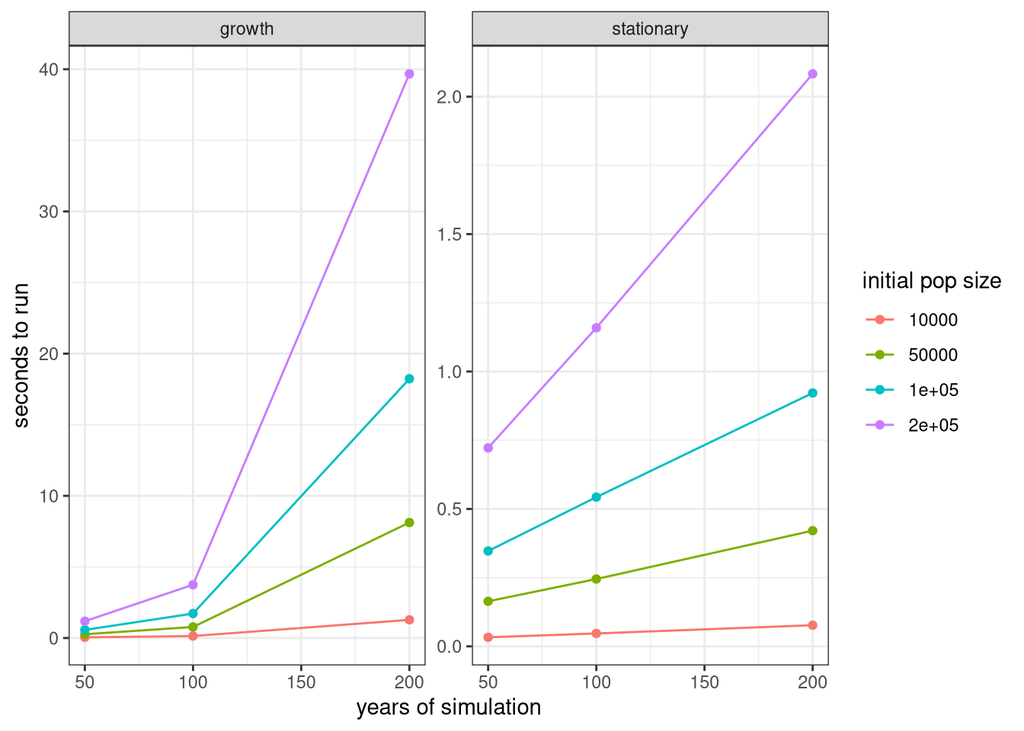

Figure 12: Time in seconds to perform each simulation. Note that the two panels do not share the same y-scale.

```r
scenarios |>
  ggplot(aes(x = time, y = elapsed_time,
    group = factor(pop_size), color = factor(pop_size)))+
  geom_line()+
  geom_point()+
  facet_wrap(~growth, scale = "free_y")+
  labs(x = "years of simulation", y = "seconds to run", color = "initial pop size")+
  theme_bw()
```

Figure 12 shows the results of the tests. When the population is stationary, increasing the length of the simulation linearly increases the time to complete the simulation, with a steeper slope for higher initial population sizes. When the population is growing, increases in the length of the simulation exponentially increase the time to complete the simulation because the underlying population is growing exponentially.

## 9 Tests

The following tests have been constructed and are currently all passing.

```r
test_results <- testthat::test_local("..", reporter = "silent")

test_table <- as.data.frame(test_results)

knitr::kable(
  test_table[, c("test", "passed", "failed", "error", "skipped", "warning")]
)
```

| test | passed | failed | error | skipped | warning |
| --- | --- | --- | --- | --- | --- |
| baseline populations are reproducible and follow the specified distributions | 10 | 0 | FALSE | FALSE | 0 |
| baseline generator supports newborns, empty populations and fractional ages | 7 | 0 | FALSE | FALSE | 0 |
| baseline generator rejects invalid arguments | 23 | 0 | FALSE | FALSE | 0 |
| live HMD and HFD downloads satisfy the rate and provenance contracts | 0 | 0 | FALSE | TRUE | 0 |
| HMD conversion selects the year and preserves rates and open ages | 10 | 0 | FALSE | FALSE | 0 |
| HFD conversion omits open ages and rejects invalid retained rates | 7 | 0 | FALSE | FALSE | 0 |
| local HMD readers preserve the upper open interval | 2 | 0 | FALSE | FALSE | 0 |
| local HFD readers preserve retained age bands | 1 | 0 | FALSE | FALSE | 0 |
| HMD downloads preserve provenance and rates can be reused without downloads | 9 | 0 | FALSE | FALSE | 0 |
| HFD downloads preserve revision metadata and rates can be reused without downloads | 10 | 0 | FALSE | FALSE | 0 |
| Lexis counts use exact exposure and maternal ages | 11 | 0 | FALSE | FALSE | 0 |
| fractional periods and ages conserve exposure | 1 | 0 | FALSE | FALSE | 0 |
| Lexis event boundaries are half open | 5 | 0 | FALSE | FALSE | 0 |
| duplicate identities in stacked histories are rejected | 1 | 0 | FALSE | FALSE | 0 |
| TFR uses band widths, omits missing rates and groups periods | 5 | 0 | FALSE | FALSE | 0 |
| life tables follow piecewise constant hazards and handle limiting cases | 20 | 0 | FALSE | FALSE | 0 |
| empty populations have zero exposure and missing mortality rates | 3 | 0 | FALSE | FALSE | 0 |
| Lexis summaries feed TFR and life tables directly | 4 | 0 | FALSE | FALSE | 0 |
| finite age breaks append an open interval | 1 | 0 | FALSE | FALSE | 0 |
| rate tables and typed processes give equivalent summaries | 5 | 0 | FALSE | FALSE | 0 |
| population counts include births and exclude deaths at each instant | 9 | 0 | FALSE | FALSE | 0 |
| all public demographic tables are tibbles including empty outputs | 8 | 0 | FALSE | FALSE | 0 |
| annual midpoints weight the current and preceding input bands | 4 | 0 | FALSE | FALSE | 0 |
| five-year band midpoints can have constant-rate renewal compensation | 2 | 0 | FALSE | FALSE | 0 |
| long spacing windows include multiple original bands and gaps | 2 | 0 | FALSE | FALSE | 0 |
| adjusted fertility uses the shared constant-hazard sampler | 2 | 0 | FALSE | FALSE | 0 |
| zero spacing and zero rates retain original bands and risks | 3 | 0 | FALSE | FALSE | 0 |
| nonpositive midpoint eligibility is rejected | 5 | 0 | FALSE | FALSE | 0 |
| open-ended fertility bands are rejected at construction and revalidation | 21 | 0 | FALSE | FALSE | 0 |
| independent mortality preserves constant fertility after burn-in | 1 | 0 | FALSE | FALSE | 0 |
| hazard inversion crosses rate bands and handles zero hazards | 4 | 0 | FALSE | FALSE | 0 |
| sampled survival matches integrated piecewise hazards | 1 | 0 | FALSE | FALSE | 0 |
| model construction retains population and rate specifications | 10 | 0 | FALSE | FALSE | 0 |
| replacing a process preserves the original model and other processes | 4 | 0 | FALSE | FALSE | 0 |
| population restarts preserve histories, endpoints and processes | 8 | 0 | FALSE | FALSE | 0 |
| population constructors normalize input subclasses to tibbles | 1 | 0 | FALSE | FALSE | 0 |
| configuration rejects invalid objects and reference times | 16 | 0 | FALSE | FALSE | 0 |
| omitted unions produce an empty union history | 6 | 0 | FALSE | FALSE | 0 |
| fractional year endpoints are retained | 1 | 0 | FALSE | FALSE | 0 |
| population construction and attachment reject inconsistent histories | 31 | 0 | FALSE | FALSE | 0 |
| custom columns and empty populations retain their structure | 2 | 0 | FALSE | FALSE | 0 |
| population validation is read only and rejects malformed objects | 8 | 0 | FALSE | FALSE | 0 |
| population attachment preserves optional metadata | 4 | 0 | FALSE | FALSE | 0 |
| sex labels are explicit and public population tables are tibbles | 10 | 0 | FALSE | FALSE | 0 |
| process constructors and setters preserve rates and replace independently | 9 | 0 | FALSE | FALSE | 0 |
| rate validation preserves custom columns and input order | 1 | 0 | FALSE | FALSE | 0 |
| invalid rates and edited process specifications are rejected | 20 | 0 | FALSE | FALSE | 0 |
| gaps are retained and public rate tables are tibbles | 4 | 0 | FALSE | FALSE | 0 |
| fertility spacing is stored and revalidated on attachment | 25 | 0 | FALSE | FALSE | 0 |
| simulation handles empty populations and zero risks | 11 | 0 | FALSE | FALSE | 0 |
| mortality survival is analytical and seeded runs preserve RNG and histories | 6 | 0 | FALSE | FALSE | 0 |
| mortality times equal continuous exponential draws | 2 | 0 | FALSE | FALSE | 0 |
| events at the run endpoint are excluded | 1 | 0 | FALSE | FALSE | 0 |
| birth precedes a later death within a former monthly bin | 2 | 0 | FALSE | FALSE | 0 |
| births preserve maternal IDs and allow initially unknown fathers | 6 | 0 | FALSE | FALSE | 0 |
| birth accounting, father availability and spacing survive restarts | 1428 | 0 | FALSE | FALSE | 0 |
| adjusted fertility follows the continuous renewal expectation | 2 | 0 | FALSE | FALSE | 0 |
| death closes existing unions without forming new unions | 3 | 0 | FALSE | FALSE | 0 |
| fractional run durations and tibble outputs are supported | 7 | 0 | FALSE | FALSE | 0 |
| nondefault process spacing is enforced and revalidated on restart | 7 | 0 | FALSE | FALSE | 0 |

## 10 Conclusions and unresolved limitations

All criteria for the milestone have been met. The microsimulation is producing results consistent with the input demographic rates and converging to stable population characteristics over time.

One remaining issue is the restart issue with changes in fertility rates. This issue will be reported as an issue on GitHub but will not be resolved for this milestone. In practice, unless restarts produce large changes in fertility, the distortion here will be minimal. Even with large changes in fertility, the distortion will only last for a few years.

## 11 Reproducibility record

```r
system2("git", c("-C", "..", "rev-parse", "HEAD"), stdout = TRUE)
```

```
[1] "c4006f72f520f423df56ac12ffe9f8414ed44d51"
```

```r
system2("git", c("-C", "..", "status", "--short"), stdout = TRUE)
```

```
[1] "?? validation/milestone1.html"      "?? validation/milestone1.rmarkdown"
```